# Assignment 7: Time Series Models

Danny Godbout

August 8, 2016

### Analysis of Time Series

This forecast will focus on the ice cream sales data. In this section, we analyze the components of the time series data and conclude that, while the data are non-stationary, a simple diff() transformation provides a stationary series. In addition, a significant seasonal component is present.

A plot of the raw ice cream sales data shows what ostensibly appears to be a stationary, seasonal time series:

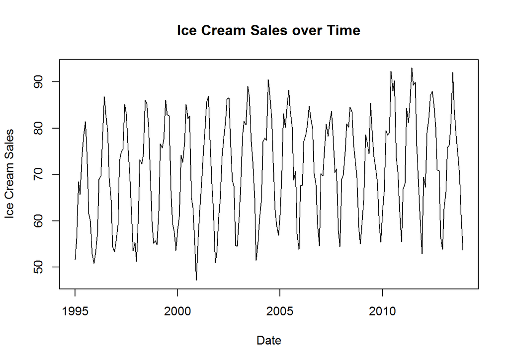

We can test for stationarity using an augmented Dickey-Fuller test. The p-value > 0.05 means the series is not stationary.

```
    Augmented Dickey-Fuller Test

data:  icecream.ts
Dickey-Fuller = -2.2608, Lag order = 12, p-value = 0.4664
alternative hypothesis: stationary
```

Running the ADF test on the diff of the icecream time series does show stationarity (p<0.05). **We will use diff(icecream) for modeling due to stationarity.**

```
    Augmented Dickey-Fuller Test

data:  diff(icecream.ts)
Dickey-Fuller = -6.8477, Lag order = 12, p-value = 0.01
alternative hypothesis: stationary
```

Checking for autocorrelation shows out-of-bounds occurences at 0.5, 1.0, 1.5… **indicating seasonality of the model.**

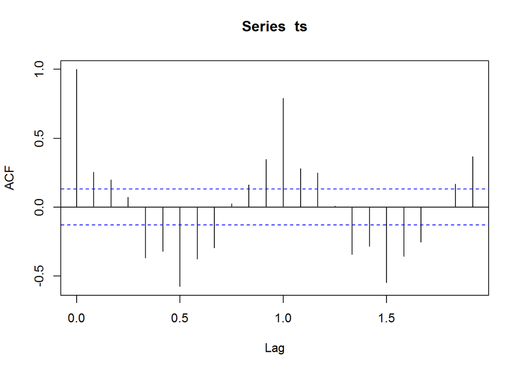

```
Autocorrelations of series 'ts', by lag

0.0000 0.0833 0.1667 0.2500 0.3333 0.4167 0.5000 0.5833 0.6667 0.7500
 1.000  0.255  0.197  0.074 -0.368 -0.320 -0.576 -0.376 -0.296  0.025
0.8333 0.9167 1.0000 1.0833 1.1667 1.2500 1.3333 1.4167 1.5000 1.5833
 0.162  0.348  0.791  0.281  0.249  0.007 -0.342 -0.285 -0.547 -0.358
1.6667 1.7500 1.8333 1.9167
-0.254  0.002  0.167  0.368
```

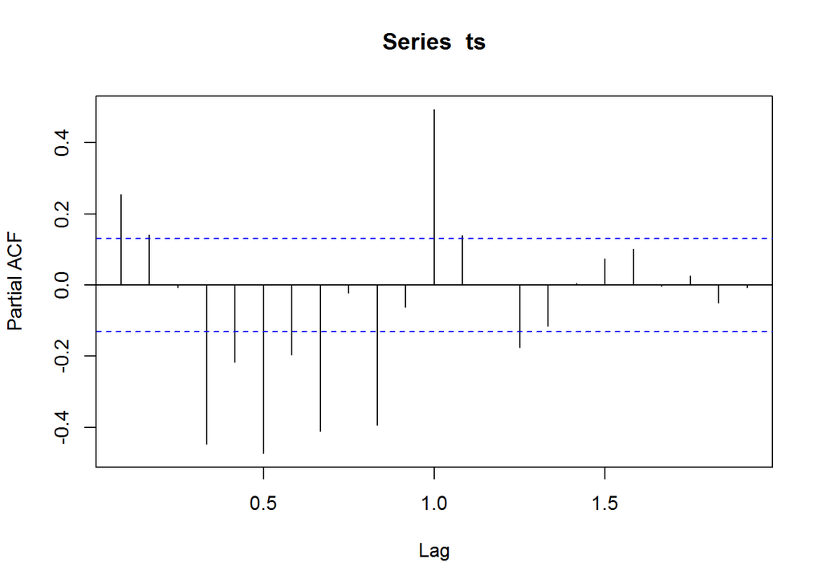

```
Partial autocorrelations of series 'ts', by lag

0.0833 0.1667 0.2500 0.3333 0.4167 0.5000 0.5833 0.6667 0.7500 0.8333
 0.255  0.141 -0.006 -0.448 -0.218 -0.473 -0.196 -0.411 -0.022 -0.395
0.9167 1.0000 1.0833 1.1667 1.2500 1.3333 1.4167 1.5000 1.5833 1.6667
-0.062  0.493  0.140  0.000 -0.175 -0.115  0.005  0.074  0.101 -0.004
1.7500 1.8333 1.9167
 0.025 -0.050 -0.007
```

Decomposing the time series, we see the seasonal component.

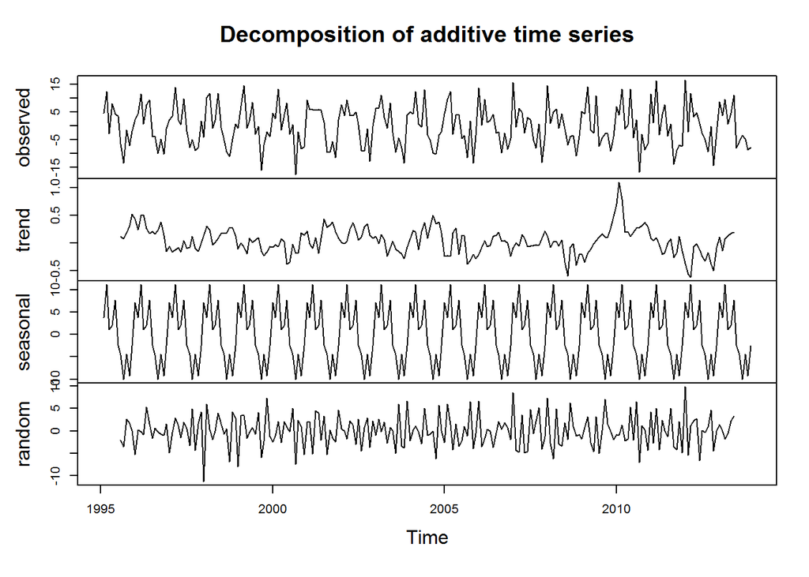

Furthermore, the random component of the decomposition appears to be randomly distributed white noise per QQ plot:

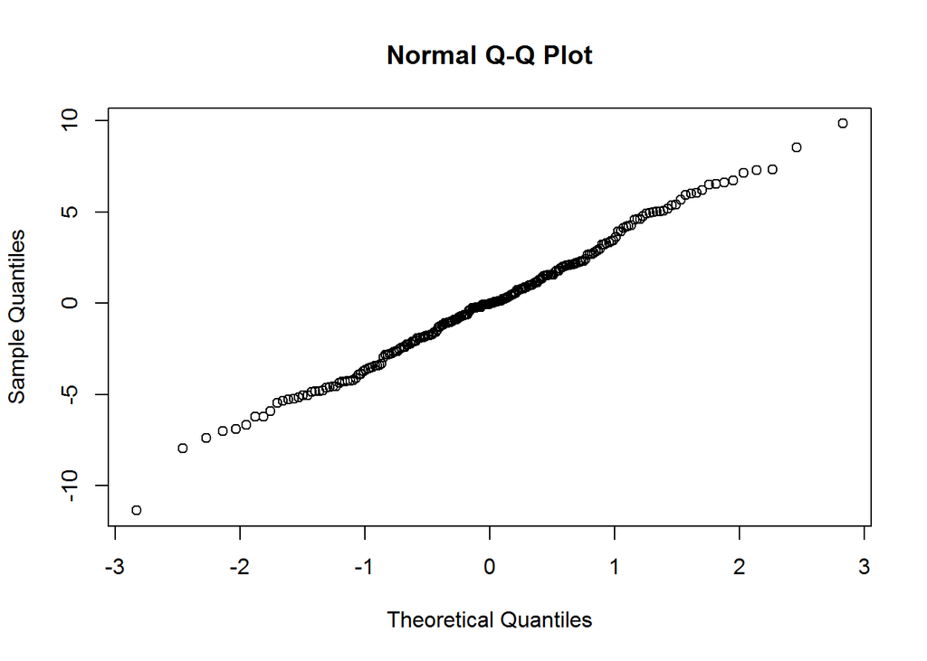

### Model

Ultimately, an **ARIMA(2,0,0)(0,1,2)[12] model was settled upon**, resulting in significant coefficients. Note that q and P coefficients were forced to 0 due to high standard errors in earlier iterations of the model.

```
Series: arma.data
ARIMA(2,0,0)(0,1,2)[12]

Coefficients:
          ar1      ar2     sma1     sma2
      -0.6507  -0.4224  -0.5142  -0.2456
s.e.   0.0622   0.0619   0.0695   0.0674

sigma^2 estimated as 8.708:  log likelihood=-540.51
AIC=1091.02   AICc=1091.31   BIC=1107.87

Training set error measures:
                     ME     RMSE      MAE       MPE     MAPE      MASE
Training set -0.0344346 2.845029 2.212862 -8.930096 98.54474 0.6579814
                    ACF1
Training set 0.005256038
```

The residuals of the model appear normal in the QQ plot. The ACF plots still show some out-of-bound occurences at approximately 6 and 18 months, perhaps implying another layer of seasonality missing from the model.

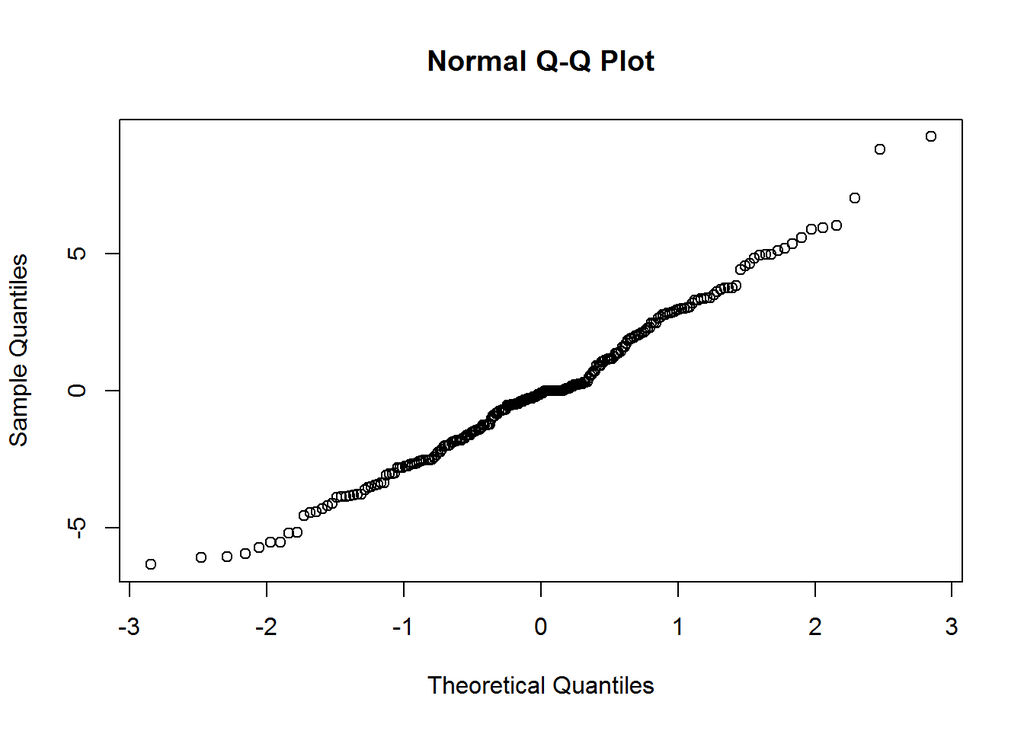

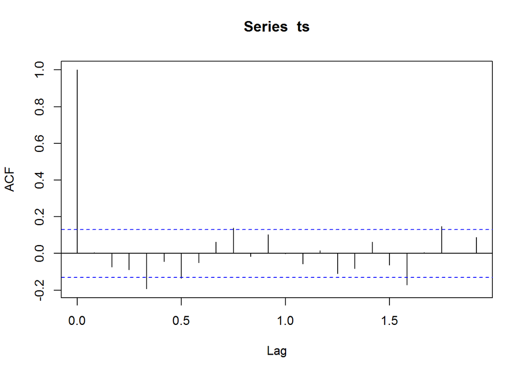

```
Autocorrelations of series 'ts', by lag

0.0000 0.0833 0.1667 0.2500 0.3333 0.4167 0.5000 0.5833 0.6667 0.7500
 1.000  0.005 -0.074 -0.088 -0.193 -0.044 -0.134 -0.049  0.063  0.139
0.8333 0.9167 1.0000 1.0833 1.1667 1.2500 1.3333 1.4167 1.5000 1.5833
-0.015  0.104 -0.002 -0.055  0.016 -0.110 -0.082  0.064 -0.063 -0.172
1.6667 1.7500 1.8333 1.9167
 0.004  0.148  0.002  0.088
```

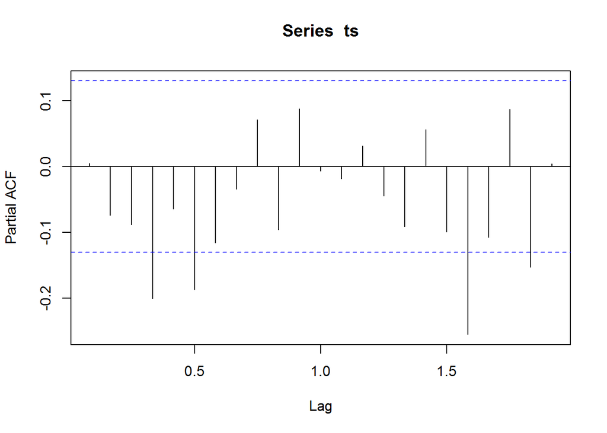

```
Partial autocorrelations of series 'ts', by lag

0.0833 0.1667 0.2500 0.3333 0.4167 0.5000 0.5833 0.6667 0.7500 0.8333
 0.005 -0.074 -0.088 -0.200 -0.064 -0.187 -0.116 -0.034  0.071 -0.096
0.9167 1.0000 1.0833 1.1667 1.2500 1.3333 1.4167 1.5000 1.5833 1.6667
 0.088 -0.007 -0.018  0.032 -0.044 -0.091  0.056 -0.099 -0.255 -0.107
1.7500 1.8333 1.9167
 0.087 -0.153  0.004
```

### Forecast

The forecast appears reasonable, with confidence intervals that are narrow enough that the model is still useful for decision making.

[output not shown]

[figure not shown]

### Source Code

```r
library(dplyr)
library(tseries)
library(forecast)


#==================
#### Load data ####
#==================

## Import the dataset
dairy.data <- read.csv('CADairyProduction.csv', header = TRUE)

## Make a time series object with ice cream production
icecream.ts <- ts(dairy.data$Icecream.Prod, start = 1995, frequency = 12)
plot(icecream.ts, xlab = "Date", ylab = "Ice Cream Sales", main = "Ice Cream Sales over Time")




#=====================================
#### Stationarity test            ####
#=====================================

## Apply stationarity tests
# Stationarity on raw data
icecream.adf <- adf.test(icecream.ts, k = 12)
icecream.adf
# Stationarity on diff of time series
icecream.diff.adf <- adf.test(diff(icecream.ts), k = 12)
icecream.diff.adf


## Based on above test, we will use the diff of the time series
## for modeling
arma.data <- diff(icecream.ts)

## Print the autocorrelation plots of the chosen time series
f_acfplots <- function(ts) {
  print(acf(ts, na.action = na.pass))
  print(pacf(ts, na.action = na.pass))
}
f_acfplots(arma.data)




#=====================================
#### Seasonality  test            ####
#=====================================

## Extract seasonality from decomposition
icecream.decompose <- decompose(arma.data)
plot(icecream.decompose)

## Do the residuals look like white noise?
qqnorm(icecream.decompose$random)

## Plot acf plots
f_acfplots(ts(icecream.decompose$random))



#=====================================
#### Model                     ####
#=====================================

## Make the final arma model
arma.model <- auto.arima(arma.data,
                         max.p=3, max.d=3, max.q=0,
                         max.P=0, max.D=3, max.Q=3,
                         max.order=5,
                         start.p=0, start.q=0,
                         start.P=0, start.Q=0)
summary(arma.model)

## acf plots of arma model
f_acfplots(arma.model$residuals)
## QQ Plot of residuals
qqnorm(arma.model$residuals)




#=====================================
#### Forecast                     ####
#=====================================

# Forecast ice cream
ts.forecast <- forecast(arma.model, h = 24)
summary(ts.forecast)

## Plot the forecast:
plot(ts.forecast)
```